# Getting My Colleagues Hooked on R

Esben Lykke

2021-10-06

## Overview

Contents:

- some stats about R
- RStudio tour (live)
- data manipulation and visualization
- learn more

## Some facts about the popularity and size of R:

- R is #7 of all programming languages ([IEEE Spectrum, 2021](https://recordtrend.com/professional-knowledge/2021-programming-language-ranking-from-ieee-spectrum/))

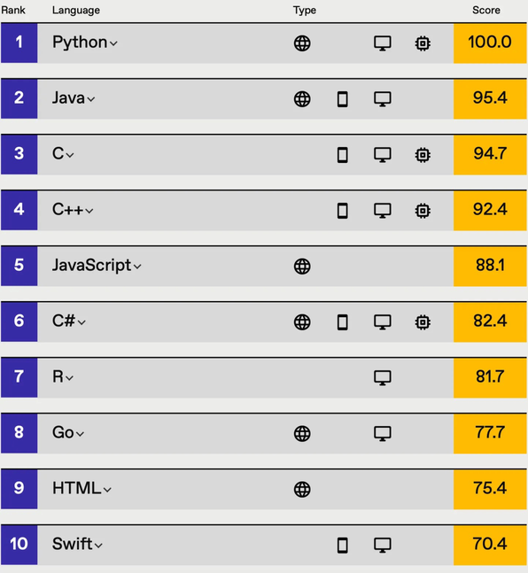

The other top languages (C, Java, Python and C++…) are all general-purpose languages, suitable for just about any programming task. R by contrast is a language specifically for data science, and its high ranking here reflects the critical importance of data science as a discipline today. In recent years, Python has surpassed R as the most used language in data science, however, it is down to the bandwagon effect! :) - Esben, 2021

- There are now **18278 ! ! !** available packages on CRAN ([CRAN: Contributed Packages, 2021-10-06](https://cran.r-project.org/web/packages/))

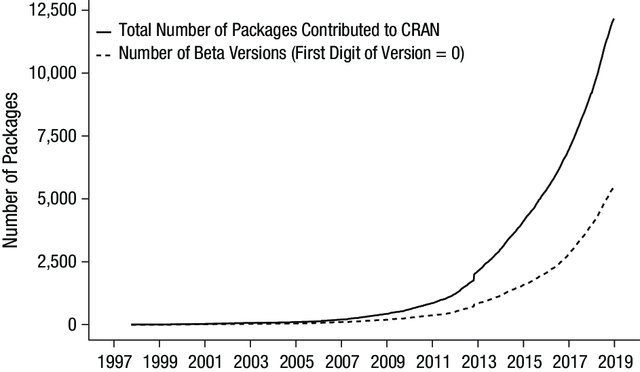

## How to use [RStudio](https://www.rstudio.com/)

- Create new project
- Panels and menus
  - rmarkdown for reports, presentations, manuscripts, whatever…
  - R script for functions, shiny ui.R files…
- Code highlighting/autocompletion
- Help and cheatsheets
- Packages, install/load
- Useful shortcuts (alt + shift + k)

## My most used packages:

- When you load the tidyverse the following suite of packages will be available:
  - ggplot2 for visualizing data.
  - dplyr for manipulating data.
  - tidyr for tidying data.
  - stingr for working with strings.
  - forcats for working with factors/categorical data.
  - purrr for functional programming, tools for working with functions and vectors.
  - readr for reading and writing .csv files (and more).
  - tibble enhanced data frames.

These are all super duper great packages. Start every R project with `library(tidyverse)`!

- More great tidyverse packages include:
  - lubridate for working with date/times.
  - hms for time-of-day values.
  - readxl for reading .xls and .xlsx files.
  - haven for SAS, SPSS, and Stata files (Traberg, hvis du vil hive gamle STATA datasæt over i R).
  - dbplyr allows you to use remote databases by converting dplyr code into SQL. Or simply write SQL directly in rmarkdown as `sql` chunks.
  - glue combine data and strings.
  - tidymodels The tidymodels framework is a collection of packages for modeling and machine learning using tidyverse principles. incredible powerfull suite of packages for machine learning. Deep learning with keras and tensorflow is also supported but are less mature (the Rstudio team is on it). Let me know if you wanna know more…
- Outside of tidyverse:
  - [janitor](https://cran.r-project.org/web/packages/janitor/vignettes/janitor.html) for quick cleaning of data.
  - [here](https://here.r-lib.org/) for operating with relative paths. A must if you wanna share your project folder.
  - [skimr](https://cran.r-project.org/web/packages/skimr/vignettes/skimr.html) for quick and comprehensive summary statistics.
  - [ggplot2 extensions](https://exts.ggplot2.tidyverse.org/gallery/) make even more beautiful plots!
  - [patchwork](https://github.com/thomasp85/patchwork/) my prefered package for combining plots.
  - [beepr](https://cran.r-project.org/web/packages/beepr/beepr.pdf) to play notification sounds. Helpful when performing time consuming tasks.

## Introduction to dplyr

We’ll use the iris dataset provided in base R. Check `library(help = "datasets")` for many more base R datasets.

```r
iris <-
  iris %>%
  as_tibble() %>%
  clean_names()

iris
```

```
# A tibble: 150 x 5
   sepal_length sepal_width petal_length petal_width species
          <dbl>       <dbl>        <dbl>       <dbl> <fct>
 1          5.1         3.5          1.4         0.2 setosa
 2          4.9         3            1.4         0.2 setosa
 3          4.7         3.2          1.3         0.2 setosa
 4          4.6         3.1          1.5         0.2 setosa
 5          5           3.6          1.4         0.2 setosa
 6          5.4         3.9          1.7         0.4 setosa
 7          4.6         3.4          1.4         0.3 setosa
 8          5           3.4          1.5         0.2 setosa
 9          4.4         2.9          1.4         0.2 setosa
10          4.9         3.1          1.5         0.1 setosa
# ... with 140 more rows
```

Dplyr aims to provide a function for each basic verb of data manipulation:

- `filter()`
- `arrange()`
- `count()`
- `select()`
- `distinct()`
- `mutate()` (and `transmute()`)
- `group_by`
- `summarise()`
- `slice_sample()`
- and more…

```r
iris %>%
  filter(sepal_length < 4.5)
```

```
# A tibble: 4 x 5
  sepal_length sepal_width petal_length petal_width species
         <dbl>       <dbl>        <dbl>       <dbl> <fct>
1          4.4         2.9          1.4         0.2 setosa
2          4.3         3            1.1         0.1 setosa
3          4.4         3            1.3         0.2 setosa
4          4.4         3.2          1.3         0.2 setosa
```

```r
iris %>%
  arrange(desc(petal_width))
```

```
# A tibble: 150 x 5
   sepal_length sepal_width petal_length petal_width species
          <dbl>       <dbl>        <dbl>       <dbl> <fct>
 1          6.3         3.3          6           2.5 virginica
 2          7.2         3.6          6.1         2.5 virginica
 3          6.7         3.3          5.7         2.5 virginica
 4          5.8         2.8          5.1         2.4 virginica
 5          6.3         3.4          5.6         2.4 virginica
 6          6.7         3.1          5.6         2.4 virginica
 7          6.4         3.2          5.3         2.3 virginica
 8          7.7         2.6          6.9         2.3 virginica
 9          6.9         3.2          5.7         2.3 virginica
10          7.7         3            6.1         2.3 virginica
# ... with 140 more rows
```

```r
iris %>%
  count(species)
```

```
# A tibble: 3 x 2
  species        n
  <fct>      <int>
1 setosa        50
2 versicolor    50
3 virginica     50
```

```r
iris %>%
  mutate(
    sepal_length_sqr = sepal_length^2,
    sepal_width = round(sepal_width)
  )
```

```
# A tibble: 150 x 6
   sepal_length sepal_width petal_length petal_width species sepal_length_sqr
          <dbl>       <dbl>        <dbl>       <dbl> <fct>              <dbl>
 1          5.1           4          1.4         0.2 setosa              26.0
 2          4.9           3          1.4         0.2 setosa              24.0
 3          4.7           3          1.3         0.2 setosa              22.1
 4          4.6           3          1.5         0.2 setosa              21.2
 5          5             4          1.4         0.2 setosa              25
 6          5.4           4          1.7         0.4 setosa              29.2
 7          4.6           3          1.4         0.3 setosa              21.2
 8          5             3          1.5         0.2 setosa              25
 9          4.4           3          1.4         0.2 setosa              19.4
10          4.9           3          1.5         0.1 setosa              24.0
# ... with 140 more rows
```

```r
iris %>%
  group_by(species) %>%
  summarise(
    mean_sepal_length = mean(sepal_length),
    median_sepal_width = median(sepal_width)
  )
```

```
# A tibble: 3 x 3
  species    mean_sepal_length median_sepal_width
  <fct>                  <dbl>              <dbl>
1 setosa                  5.01                3.4
2 versicolor              5.94                2.8
3 virginica               6.59                3
```

## A quick comparison between the syntax of pandas and dplyr

Pandas is python’s equivalent of dplyr, e.i. the preferred package for data wrangling.

### Load data

```python
import pandas as pd
from gapminder import gapminder

gapminder.head()
```

```
       country continent  year  lifeExp       pop   gdpPercap
0  Afghanistan      Asia  1952   28.801   8425333  779.445314
1  Afghanistan      Asia  1957   30.332   9240934  820.853030
2  Afghanistan      Asia  1962   31.997  10267083  853.100710
3  Afghanistan      Asia  1967   34.020  11537966  836.197138
4  Afghanistan      Asia  1972   36.088  13079460  739.981106
```

```r
library(tidyverse)
library(gapminder)

head(gapminder)
```

```
# A tibble: 6 x 6
  country     continent  year lifeExp      pop gdpPercap
  <fct>       <fct>     <int>   <dbl>    <int>     <dbl>
1 Afghanistan Asia       1952    28.8  8425333      779.
2 Afghanistan Asia       1957    30.3  9240934      821.
3 Afghanistan Asia       1962    32.0 10267083      853.
4 Afghanistan Asia       1967    34.0 11537966      836.
5 Afghanistan Asia       1972    36.1 13079460      740.
6 Afghanistan Asia       1977    38.4 14880372      786.
```

### Filter data

```python
gapminder[gapminder['year'] == 2007]
```

```
                 country continent  year  lifeExp       pop     gdpPercap
11           Afghanistan      Asia  2007   43.828  31889923    974.580338
23               Albania    Europe  2007   76.423   3600523   5937.029526
35               Algeria    Africa  2007   72.301  33333216   6223.367465
47                Angola    Africa  2007   42.731  12420476   4797.231267
59             Argentina  Americas  2007   75.320  40301927  12779.379640
...                  ...       ...   ...      ...       ...           ...
1655             Vietnam      Asia  2007   74.249  85262356   2441.576404
1667  West Bank and Gaza      Asia  2007   73.422   4018332   3025.349798
1679         Yemen, Rep.      Asia  2007   62.698  22211743   2280.769906
1691              Zambia    Africa  2007   42.384  11746035   1271.211593
1703            Zimbabwe    Africa  2007   43.487  12311143    469.709298

[142 rows x 6 columns]
```

```r
gapminder %>%
  filter(year == 2007)
```

```
# A tibble: 142 x 6
   country     continent  year lifeExp       pop gdpPercap
   <fct>       <fct>     <int>   <dbl>     <int>     <dbl>
 1 Afghanistan Asia       2007    43.8  31889923      975.
 2 Albania     Europe     2007    76.4   3600523     5937.
 3 Algeria     Africa     2007    72.3  33333216     6223.
 4 Angola      Africa     2007    42.7  12420476     4797.
 5 Argentina   Americas   2007    75.3  40301927    12779.
 6 Australia   Oceania    2007    81.2  20434176    34435.
 7 Austria     Europe     2007    79.8   8199783    36126.
 8 Bahrain     Asia       2007    75.6    708573    29796.
 9 Bangladesh  Asia       2007    64.1 150448339     1391.
10 Belgium     Europe     2007    79.4  10392226    33693.
# ... with 132 more rows
```

Filter on multiple conditions.

```python
gapminder[(gapminder['year'] == 2007) & (gapminder['continent'] == 'Americas') & (gapminder['country'] == 'United States')]
```

```
            country continent  year  lifeExp        pop    gdpPercap
1619  United States  Americas  2007   78.242  301139947  42951.65309
```

```r
gapminder %>%
  filter(year == 2007,
         continent == "Americas",
         country == "United States")
```

```
# A tibble: 1 x 6
  country       continent  year lifeExp       pop gdpPercap
  <fct>         <fct>     <int>   <dbl>     <int>     <dbl>
1 United States Americas   2007    78.2 301139947    42952.
```

### Summary stats

Calculate the total population per continent in 2007 and sort the results in descending order.

```python
gapminder[gapminder['year'] == 2007].groupby(by='continent').sum()['pop'].sort_values(ascending=False)
```

```
continent
Asia        3811953827
Africa       929539692
Americas     898871184
Europe       586098529
Oceania       24549947
Name: pop, dtype: int64
```

```r
gapminder %>%
  filter(year == 2007) %>%
  group_by(continent) %>%
  summarize(total_pop = sum(pop)) %>%
  arrange(desc(total_pop))
```

```
# A tibble: 5 x 2
  continent  total_pop
  <fct>          <dbl>
1 Asia      3811953827
2 Africa     929539692
3 Americas   898871184
4 Europe     586098529
5 Oceania     24549947
```

## Creating derived variables

Print top ten countries in the 90th percentile with regards to GDP per capita in 2007.

```python
gapminder_2007 = gapminder[gapminder['year'] == 2007]
gapminder_2007['percentile'] = gapminder_2007['gdpPercap'].rank(pct=True)
gapminder_2007.sort_values(by='percentile', ascending=False)[:10]
```

```
               country continent  year  ...        pop    gdpPercap  percentile
1151            Norway    Europe  2007  ...    4627926  49357.19017    1.000000
863             Kuwait      Asia  2007  ...    2505559  47306.98978    0.992958
1367         Singapore      Asia  2007  ...    4553009  47143.17964    0.985915
1619     United States  Americas  2007  ...  301139947  42951.65309    0.978873
755            Ireland    Europe  2007  ...    4109086  40675.99635    0.971831
671   Hong Kong, China      Asia  2007  ...    6980412  39724.97867    0.964789
1487       Switzerland    Europe  2007  ...    7554661  37506.41907    0.957746
1091       Netherlands    Europe  2007  ...   16570613  36797.93332    0.950704
251             Canada  Americas  2007  ...   33390141  36319.23501    0.943662
695            Iceland    Europe  2007  ...     301931  36180.78919    0.936620

[10 rows x 7 columns]
```

```r
gapminder %>%
  filter(year == 2007) %>%
  mutate(percentile = ntile(gdpPercap, 100)) %>%
  arrange(desc(percentile)) %>%
  top_n(10)
```

```
# A tibble: 10 x 7
   country          continent  year lifeExp       pop gdpPercap percentile
   <fct>            <fct>     <int>   <dbl>     <int>     <dbl>      <int>
 1 Norway           Europe     2007    80.2   4627926    49357.        100
 2 Kuwait           Asia       2007    77.6   2505559    47307.         99
 3 Singapore        Asia       2007    80.0   4553009    47143.         98
 4 United States    Americas   2007    78.2 301139947    42952.         97
 5 Ireland          Europe     2007    78.9   4109086    40676.         96
 6 Hong Kong, China Asia       2007    82.2   6980412    39725.         95
 7 Switzerland      Europe     2007    81.7   7554661    37506.         94
 8 Netherlands      Europe     2007    79.8  16570613    36798.         93
 9 Canada           Americas   2007    80.7  33390141    36319.         92
10 Iceland          Europe     2007    81.8    301931    36181.         91
```

```r
# nate that top_n uses the last var in the tbl for ordering as default. Write top_n(10, wt = var_you_wanna_order_by) if not the last var in tbl.
```

Both python and R are great languages for data science, however, the tidyverse syntax seems to be cleaner and easier to read.

The chapter on data [wrangling](https://r4ds.had.co.nz/wrangle-intro.html) in the r4ds book is a great way to get to know data wrangling in R.

## Elegant visualization with [ggplot2](http://ggplot2.org/)

mtcars is another dataset provided in base R.

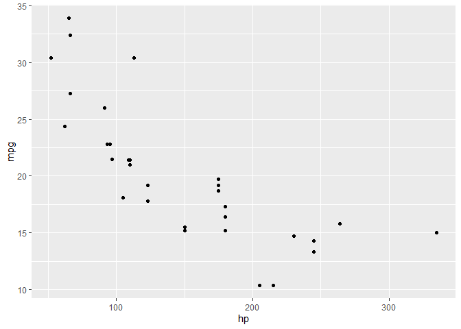

```r
mtcars <-
  mtcars %>%
  rownames_to_column(var = "model")

p <-
  mtcars %>%
  ggplot(aes(hp, mpg)) +
  geom_point()

p
```

## Adding layers

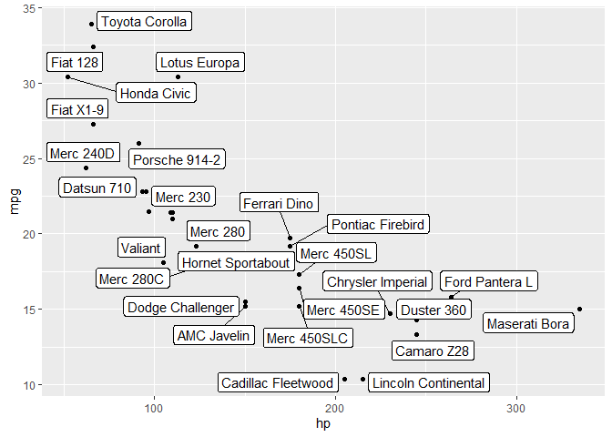

```r
p + geom_label_repel(aes(label = model))
```

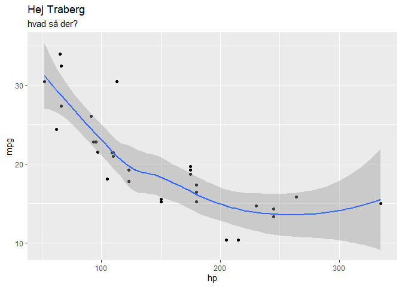

```r
mtcars %>%
  ggplot(aes(hp, mpg)) +
  geom_point() +
  geom_smooth() +
  labs(
    title = "Hej Traberg",
    subtitle = "hvad så der?",
    color = "automatic?"
  ) +
  scale_color_discrete(labels = c("yes", "no"))
```

```r
iris2 <-
  iris %>%
  mutate(hej = sepal_length + 100)
```

## Many plots combined with patchwork

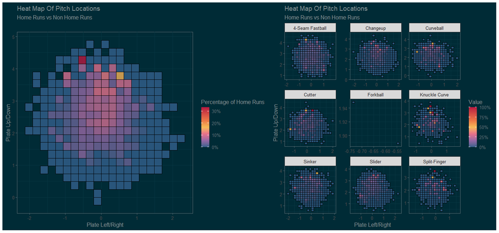

```r
p5 + p6
```

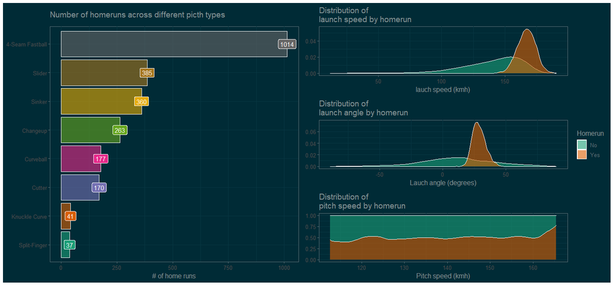

```r
p1 | (p2 / p3 / p4 + plot_layout(guides = "collect")) +
  theme_solarized(light = FALSE)
```

## Advanced plots, go crazy

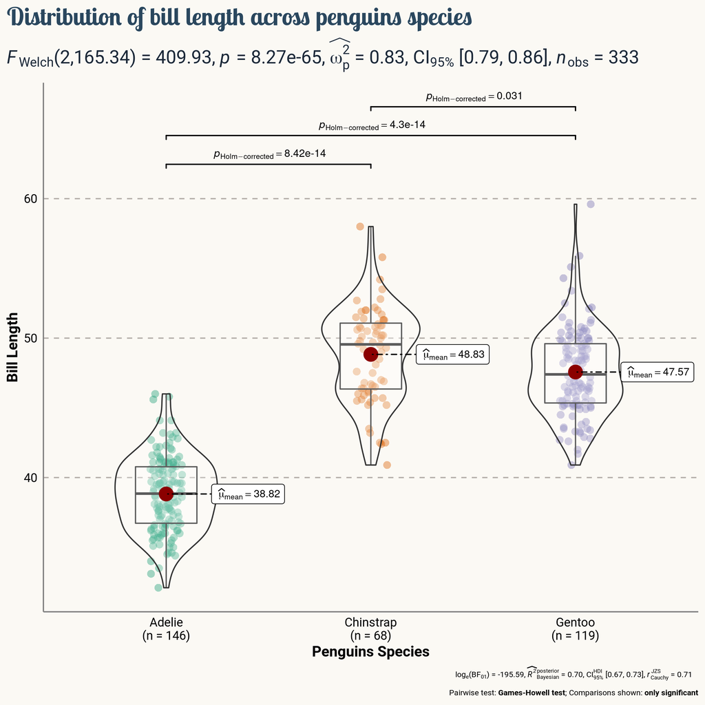

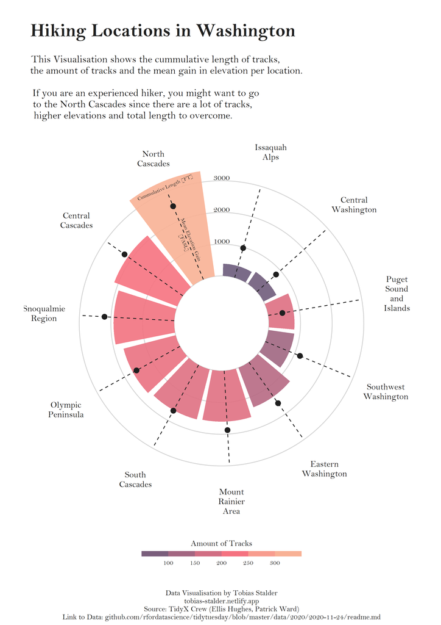

## More bling for plots

Looking for inspiration or help concerning data visualisation with R? Go check:

- [R graph gallery](http://www.r-graph-gallery.com/)
- [ggplot2 extensions gallery](https://exts.ggplot2.tidyverse.org/gallery/)

## Interactive apps with [Shiny](http://shiny.rstudio.com/)

- Check out the [shiny exemples gallery](https://shiny.rstudio.com/gallery/)

## Free books to learn about R:

- Data analysis:
  - [R for Data Science](http://r4ds.had.co.nz/)
  - [An Introduction to Statistical Learning, with Applications in R](http://www-bcf.usc.edu/~gareth/ISL/)
- Data vizualisation:
  - Elegant Graphics for Data Analysis
- Reporting:
  - [Getting used to R, RStudio, and R Markdown](https://ismayc.github.io/rbasics-book/index.html)
- Advanced R programming:
  - [Efficient R Programming](https://csgillespie.github.io/efficientR/preface.html)
  - [Advanced R](http://adv-r.had.co.nz/) Shiny apps:
  - [Mastering Shiny](https://mastering-shiny.org/)
- Package development:
  - [R packages](http://r-pkgs.had.co.nz/)

Learn: [R Course Finder](http://r-exercises.com/r-courses/)

## Some of the content that I subscribe to:

- Medium.com for short articles on all topics within data science (not just R-related).
- Content creators:
  - [David Robinson](https://www.youtube.com/user/safe4democracy) does excellent EDA and modeling (sliced 2021 winner).
  - [Julia Silge](https://www.youtube.com/c/JuliaSilge) mostly does introduction to different models and pretty plots.
  - [Andrew Couch](https://www.youtube.com/c/AndrewCouch) does great introductions to the best R packages.
  - [Jesse Mostipak](https://www.twitch.tv/kierisi) does learn-along streams on Shiny apps among other.
  - [Nick Wan](https://www.twitch.tv/nickwan_datasci) hosts the competitive data science show, Sliced. :)
  - [Cedric Sherer](https://www.cedricscherer.com/) blog mostly on pretty vizualisations.